# Estudo R for Data Science - Cap 2

Bruno de A. Machado

9/20/2020

# Visualização de Dados

[R for Data Science](https://r4ds.had.co.nz/index.html)

Neste segundo capítulo os autores nos ensinam como visualizar dados utilizando `ggplot2` e apresenta o conceito de **gramática dos gráficos** e como criar plots em camadas.

Importando o pacote tidyverse para que nos fornece o `ggplot2` entre outros :

```r
library(tidyverse)
```

## Usando o primeiro gráfico para responder algumas perguntas :

**1. Carros com motores maiores consomem mais combustível que carros com motores menores ?**

- `displ` : engine size em litros
- `hwy` : eficiencia em miles per gallon (mpg), um carro com baixa eficiencia consome mais combustivel .

  **Resposta**: Podemos observar essa relação que é de conhecimento comum que carros com menor eficiência com relação a combustível `hwy` tem os maiores motores `displ`

**2. Qual o relacionamento entre `engine size (displ)` e `efficience (hwy)` ?**

**Resposta**: Relaçao negativa entre as duas variáveis, ou seja, carros com engines maiores são menos eficientes e usam mais combustível

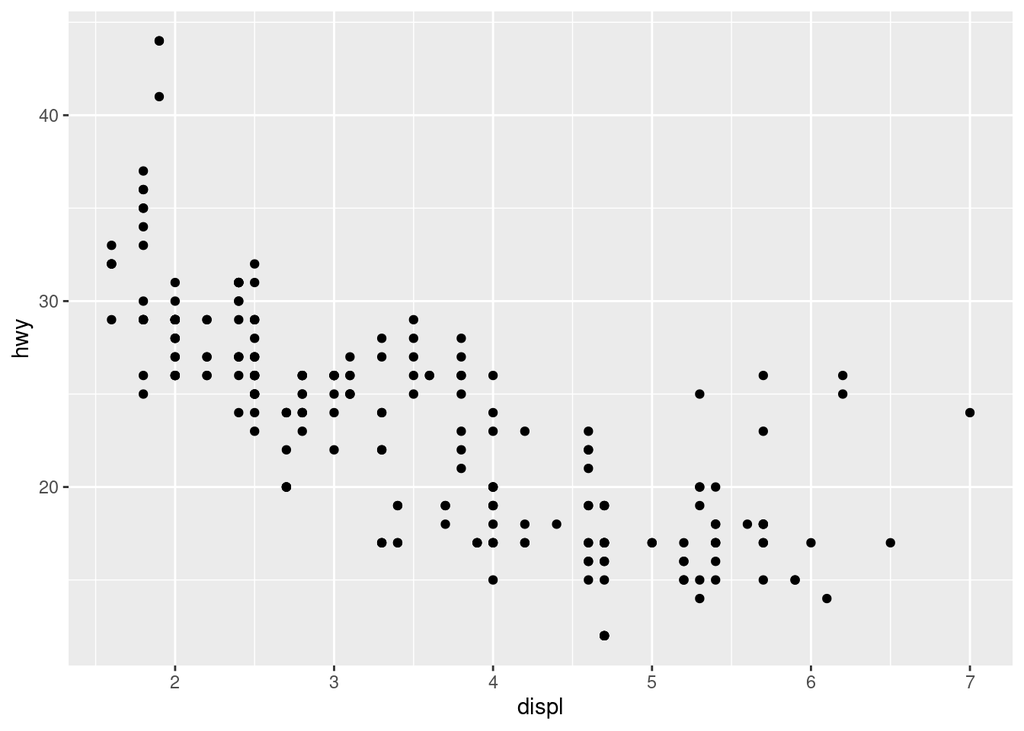

```r
ggplot(data = mpg) +
  geom_point(mapping = aes(x = displ, y = hwy))
```